# homework12md8-9

Author

Andrew Myerson

# Homework 12 MD 8-9

```r
#/ message: false
library(tidyverse)
library(moderndive)
library(infer)
```

## Question 1

```r
set.seed(1108)

poll <- tibble(
  vote_gop = rbinom(n = 1000,
                    size = 1,
                    prob = .53))
```

```r
head(poll, n = 10)
```

```
# A tibble: 10 × 1
   vote_gop
      <int>
 1        0
 2        1
 3        0
 4        0
 5        0
 6        1
 7        0
 8        0
 9        0
10        0
```

```r
poll |>
  summarize(mean = mean(poll$vote_gop))
```

```
# A tibble: 1 × 1
   mean
  <dbl>
1 0.515
```

Bootstrap 95% percent confidence interval for GOP (Republican) vote share based on this poll:

First way:

```r
boot_v1 <- poll |>
  rep_sample_n(size = 100, replace = TRUE, reps = 1000) |>
  group_by(replicate) |>
  summarize(prop_gop = mean(vote_gop))

quantile(boot_v1$prop_gop, c(.025, .975))
```

```
 2.5% 97.5%
 0.41  0.61
```

Estimated 95% confidence interval #1 = (0.41, 0.61).

Second way:

```r
boot_v2 <- poll |>
  specify(response = vote_gop) |>
  generate(reps = 1000) |>
  calculate(stat = "mean")
```

```
Setting `type = "bootstrap"` in `generate()`.
```

```r
glimpse(boot_v2)
```

```
Rows: 1,000
Columns: 2
$ replicate <int> 1, 2, 3, 4, 5, 6, 7, 8, 9, 10, 11, 12, 13, 14, 15, 16, 17, 1…
$ stat      <dbl> 0.523, 0.509, 0.513, 0.508, 0.500, 0.527, 0.508, 0.510, 0.52…
```

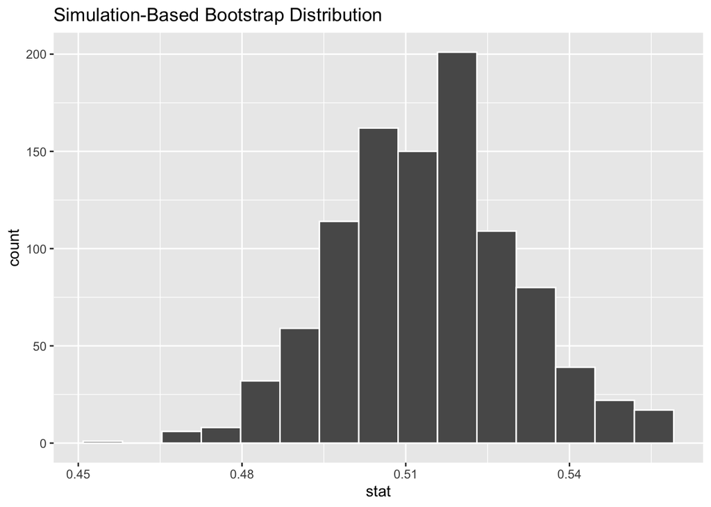

```r
visualize(boot_v2)
```

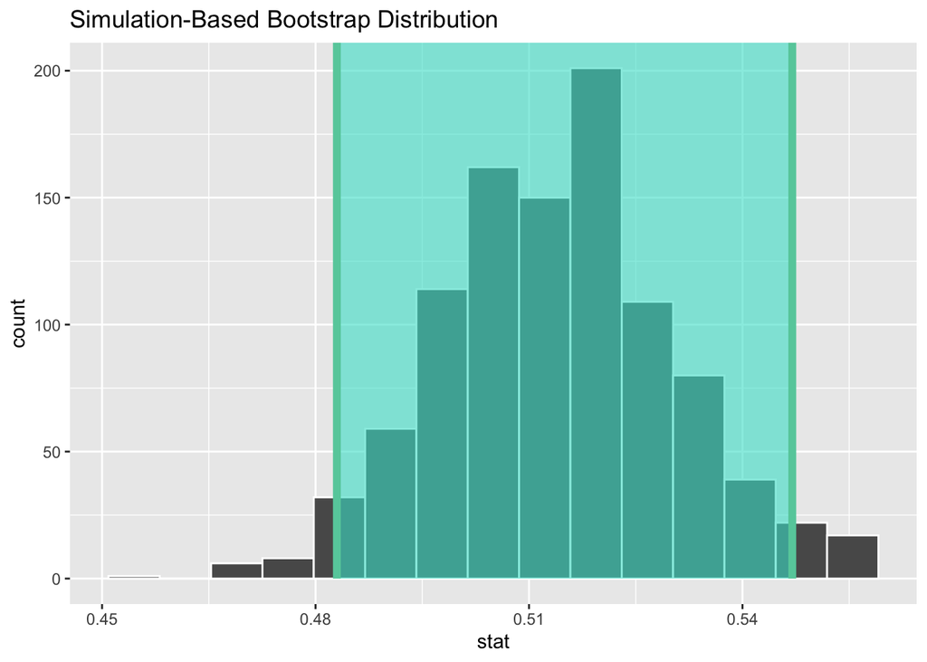

```r
ci_2 <- boot_v2 |>
  get_ci(level = .95)


boot_v2 |>
  visualize() + shade_confidence_interval(ci_2)
```

Estimated 95% confidence interval #2 = (0.483, 0.547).

## History of Rap

```r
rap_poll <- read_csv("https://raw.githubusercontent.com/rfordatascience/tidytuesday/master/data/2020/2020-04-14/polls.csv")
```

```r
rap_1 <- rap_poll |>
  group_by(critic_name) |>
  filter(rank == 1)
```

## Question 2

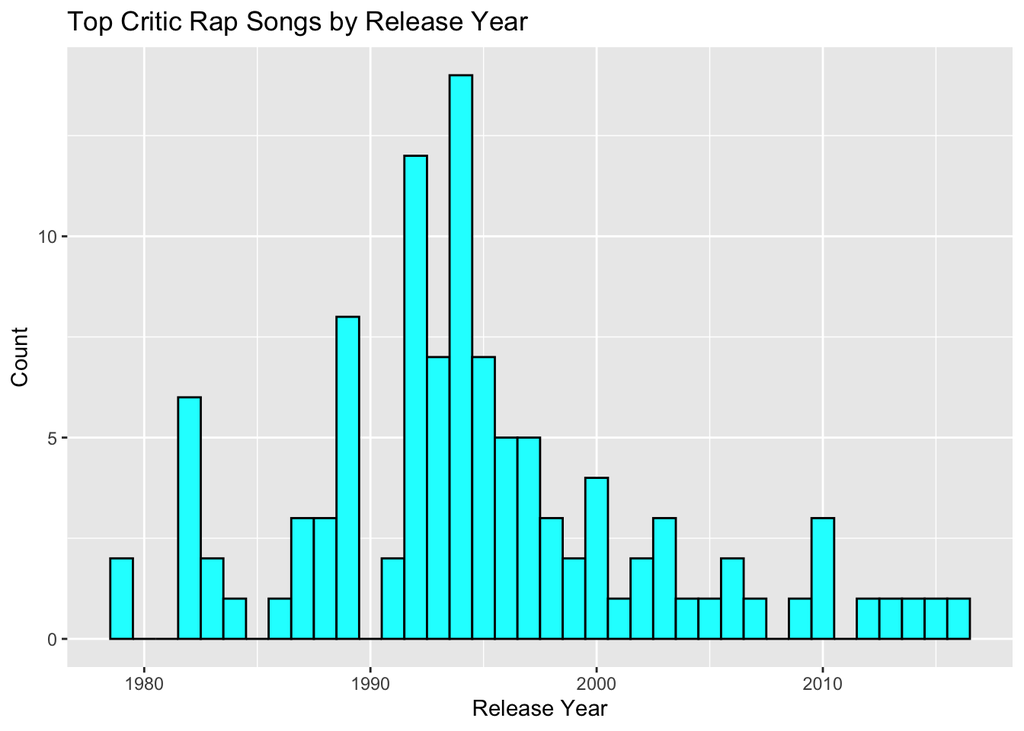

```r
ggplot(rap_1,
       mapping = aes(x = year)) +
  geom_histogram(binwidth = 1, fill = "cyan", color = "black", center = 0) +
  labs(x = "Release Year",
       y = "Count",
       title = "Top Critic Rap Songs by Release Year")
```

The year of the most commonly named favorite track in this critic poll is **1994**, when **14** artists named a track from this year.

## Question 3

```r
set.seed(11)

ci_rap <- rap_1 |>
  rep_sample_n(size = 107, replace = TRUE, reps = 1000) |>
  group_by(replicate) |>
  summarize(mean_year = mean(year))

quantile(ci_rap$mean_year, c(.025, .975))
```

```
    2.5%    97.5%
1993.364 1996.271
```

Upper bound is 1996 and lower bound is 1993, rounded to the nearest year, for the 95% confidence interval for the peak of rap.

## Question 4

```r
set.seed(11)

ci_rap25 <- rap_1 |>
  rep_sample_n(size = 25, replace = TRUE, reps = 1000) |>
  group_by(replicate) |>
  summarize(mean_year = mean(year))

quantile(ci_rap25$mean_year, c(.025, .975))
```

```
   2.5%   97.5%
1991.68 1998.08
```

The 95% confidence interval for the peak of rap when using a sample size of 25 is wider than when using the full sample size of 107, ranging from 1992 to 1998 (6 years instead of 3 years). There is more variation when using a smaller sample size so the confidence interval is wider.

## CHAPTER 9

```r
pl_data <- read_csv("https://raw.githubusercontent.com/vaiseys/dav-course/main/Data/premier_league.csv")
glimpse(pl_data)
```

```
Rows: 380
Columns: 4
$ home_team  <chr> "Bournemouth", "Chelsea", "Everton", "Leicester", "Man Unit…
$ away_team  <chr> "Aston Villa", "Swansea", "Watford", "Sunderland", "Tottenh…
$ score_diff <dbl> -1, 0, 0, 2, 1, -2, -2, 0, -1, -3, -1, -3, -2, 2, 0, 0, -1,…
$ result     <chr> "aw", "d", "d", "hw", "hw", "aw", "aw", "d", "aw", "aw", "a…
```

## Question 5

```r
pl_data |>
  filter(result == "hw") |>
  summarize(proportion_of_hw = n() / nrow(pl_data))
```

```
# A tibble: 1 × 1
  proportion_of_hw
             <dbl>
1            0.413
```

The proportion of home wins during the 2015-16 Premier League season (the best league in the world) is 0.413.

## Question 6

```r
set.seed(22)

sampled_proportions <- c()

for (i in 1:1000) {

  sampled_results <- sample(c("aw", "hw" , "d"),
                            size = 380,
                            replace = TRUE,
                            prob = c(1/3,1/3,1/3))
  prop <- sum(sampled_results == "hw")/380
  sampled_proportions[i] <- prop

}
```

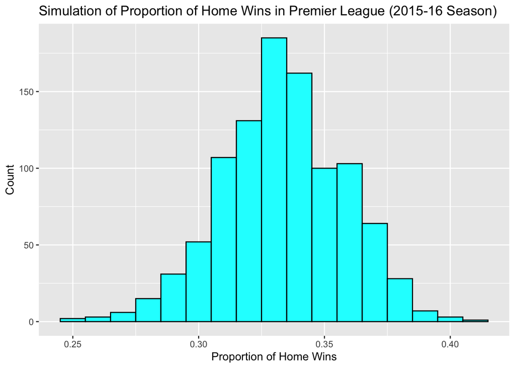

```r
proportion_hw_test <- data.frame(proportions = sampled_proportions)


ggplot(proportion_hw_test,
       mapping = aes(x = proportions)) +
  geom_histogram(binwidth = 0.01, fill = "cyan", color = "black") +
  labs(x = "Proportion of Home Wins",
       y = "Count",
       title = "Simulation of Proportion of Home Wins in Premier League (2015-16 Season)")
```

```r
proportion_hw_test |>
  summarize(mean_hw = (mean(proportions)))
```

```
    mean_hw
1 0.3336632
```

The histogram displaying the simulation sampling distribution for the proportion of home wins during the Premier League 2015-2016 season, if it were equally likely for the home team to win, lose, or draw, is roughly symmetrical and bell-shaped with a mean of about 0.334. This makes sense because this is equal to 1/3 - the probability we set for the home team to win in the simulation.

The proportion of home wins that we would expect if a home win was as equally likely as any other result is 1/3 or 0.333, while the proportion I found in Question 5 is 0.413. Therefore our observed value is **greater than our expected value under the null hypothesis** that each result is equally likely, so we can start to possibly infer that home wins has a greater proportion than 1/3.

## Question 7

The null hypothesis in this scenario is that there is an equal proportion of 1/3 of home wins, loses or draws in the 2015-16 Premier League Season. There is no difference in the proportion of home wins compared to loses or draws. We assumed this to be true when making the histogram in Question 6.

The alternative hypothesis is that there is a home field advantage and teams who play at home - with their own fans - win more on average. Therefore, the proportion of home wins would be greater than 1/3.

## Question 8

In general, a p-value is the probability of obtaining a test statistic as or more extreme than the expected test statistic when we assume the null hypothesis is true. In this case, our alternative hypothesis is that the proportion of home wins is GREATER than 0.333, so we change the language from “as or more extreme” to “as far or farther above”.

A p-value in this scenario would be the probability of observing a test statistic of the observed proportion of home wins as far or farther above 0.333, when assuming that the null hypothesis that there is an equal proportion of 1/3 of home wins, loses or draws in the 2015-16 Premier League Season is true.